# Lab 10 - Jin Kweon - 3032235207

Jin Kweon

11/3/2017

# KNN

Good reference: https://www.datacamp.com/community/tutorials/machine-learning-in-r

Q. How does tie arise if we set k is odd and not multiple of group number…???

Q. How to do make distance with matrix? It seems not really working when converting between factor and string???

```r
set.seed(103)
iris %>% ggvis(~Sepal.Length, ~Sepal.Width, fill = ~Species) %>% layer_points()
```

[output not shown]

```r
iris %>% ggvis(~Petal.Length, ~Petal.Width, fill = ~Species) %>% layer_points()
```

[output not shown]

```r
summary(iris) #check whether need to normalize it!
```

```
##   Sepal.Length    Sepal.Width     Petal.Length    Petal.Width
##  Min.   :4.300   Min.   :2.000   Min.   :1.000   Min.   :0.100
##  1st Qu.:5.100   1st Qu.:2.800   1st Qu.:1.600   1st Qu.:0.300
##  Median :5.800   Median :3.000   Median :4.350   Median :1.300
##  Mean   :5.843   Mean   :3.057   Mean   :3.758   Mean   :1.199
##  3rd Qu.:6.400   3rd Qu.:3.300   3rd Qu.:5.100   3rd Qu.:1.800
##  Max.   :7.900   Max.   :4.400   Max.   :6.900   Max.   :2.500
##        Species
##  setosa    :50
##  versicolor:50
##  virginica :50
##
##
##
```

```r
# normalize <- function(x){
#   output <- (x - min(x)) / (max(x) - min(x))
#   return(output)
# }
# lapply(iris[,-5], normalize)


#1. combine xtrain and y train
#2. Nested for loop for each new observation to compare distance with train and put into vector
#3. Compare each distance and find k smallest distance
#4. Count how many k smallest distance belong to each group, and that new observation is belonged to the group where many groups involved...


my_knn <- function(xtrain, xtest, ytrain, k){
  euclid <- function(x, w){
    dist <- sqrt(sum((x - w)^2))
    return(dist)
  }
  combined <- cbind(xtrain, ytrain)
  splited <- split(train_set[, -5], train_set$Species)

  testnumber <- nrow(xtest)
  trainnumber <- nrow(xtrain)

  #distance <- matrix(0, testnumber, trainnumber)

  #matrix function really does not work efficiently....
  # for(i in 1:testnumber){
  #   for(j in 1:trainnumber){
  #     distance[i, j] <- euclid(xtest[i, ], xtrain[j, ])
  #
  #   }
  # }
  #
  # kmin <- data.frame()
  # for(i in 1:testnumber){
  #   for(j in 1:5){
  #     kmin[i, j] <- as.character(ytrain[order(distance[i,])[j]])
  #   }
  # }

  kmins <- c()
  for(i in 1:testnumber){
    distance <- c()
    kmin <- c()
    for(j in 1:trainnumber){
      distance[j] <- euclid(xtest[i, ], xtrain[j, ])
    }
    kmin <- ytrain[order(distance)[1:k]]
    kmin <- names(which.max(table(kmin)))
    kmins[i] <- kmin
  }
  factor(kmins, levels = c("setosa", "versicolor", "virginica"))
  return(kmins)
}

train_idx <- sample(nrow(iris), 90)
train_set <- iris[train_idx, ]
test_set <- iris[-train_idx, ]

#k = 1 implies letting the group that is the closest!!!
#choose k not odd and not multiple of class numbers... => main drawback...
my_knn_pred <- my_knn(train_set[, -5], test_set[, -5], train_set$Species, k=1)
knn_pred <- knn(train_set[, -5], test_set[, -5], train_set$Species, k=1)
table(my_knn_pred == knn_pred)
```

```
##
## TRUE
##   60
```

# KNN CV

Reference: http://dataaspirant.com/2017/01/09/knn-implementation-r-using-caret-package/ http://genomicsclass.github.io/book/pages/crossvalidation.html

Q. Do we partition train set into another training and testing for CV???

```r
set.seed(20)

find_k_cv <- function(xtrain, ytrain, k = 1:10, nfold = 10){
  set.seed(17)
  foldsmatrix <- matrix(0, max(k), nfold)
  folds <- createFolds(1:nrow(xtrain))

  for(i in 1:max(k)){
    for(j in 1:nfold){
      #or use my_knn function ... but it takes too much time...
      knn <- knn(xtrain[-folds[[j]], ], xtrain[folds[[j]], ], ytrain[-folds[[j]]], i)
      foldsmatrix[i, j] <-  mean(knn != ytrain[folds[[j]]])

    }
  }
  lists <- list(foldsmatrix, which.min(apply(foldsmatrix, 1, mean)))
  return(lists)
}

find_k_cv(train_set[, -5], train_set[, 5])
```

```
## [[1]]
##            [,1]      [,2] [,3] [,4] [,5] [,6] [,7]      [,8] [,9]
##  [1,] 0.1111111 0.1111111    0    0    0    0    0 0.1111111    0
##  [2,] 0.2222222 0.1111111    0    0    0    0    0 0.1111111    0
##  [3,] 0.2222222 0.1111111    0    0    0    0    0 0.1111111    0
##  [4,] 0.1111111 0.2222222    0    0    0    0    0 0.1111111    0
##  [5,] 0.1111111 0.1111111    0    0    0    0    0 0.1111111    0
##  [6,] 0.1111111 0.1111111    0    0    0    0    0 0.0000000    0
##  [7,] 0.1111111 0.1111111    0    0    0    0    0 0.0000000    0
##  [8,] 0.1111111 0.1111111    0    0    0    0    0 0.0000000    0
##  [9,] 0.1111111 0.1111111    0    0    0    0    0 0.0000000    0
## [10,] 0.0000000 0.1111111    0    0    0    0    0 0.0000000    0
##           [,10]
##  [1,] 0.3333333
##  [2,] 0.3333333
##  [3,] 0.2222222
##  [4,] 0.2222222
##  [5,] 0.0000000
##  [6,] 0.2222222
##  [7,] 0.1111111
##  [8,] 0.1111111
##  [9,] 0.2222222
## [10,] 0.2222222
##
## [[2]]
## [1] 5
```

```r
#which.min(apply(cvmat, 1, mean))
```

# Comparison

Q. For scenario 2, the mean is (4, 4), but why the given function is (1, 1)??? Doesn’t it have to be (1, 1), otherwise, it will give glm.fit: algorithm did not converge" message… And, #4 sigma orders wrong… And, #4 says simulate 40 observations, but simulate 100 observations… All the scenarios should have same number of observations for the test??? And, #6 says simulate n observations, and did not tell you how many exactly…

Q. I dont really understand the logic for scenario 3 codes..???

```r
set.seed(30)

expit <- function(x){
  exp(x) / (1 + exp(x))
}

gen_datasets <- function(){
  #1
  id <- diag(c(1, 1))
  df1 <- data.frame(y=factor(rep(c(0, 1), each=50)),
                    rbind(rmvnorm(50, mean=c(0, 0), sigma = id),
                          rmvnorm(50, mean=c(1, 1), sigma = id)))


  #2
  covmat <- matrix(c(1, -0.5, -0.5, 1), nrow=2)
  df2 <- data.frame(y=factor(rep(c(0, 1), each=50)),
                    rbind(rmvnorm(50, mean=c(0, 0), sigma = covmat),
                          rmvnorm(50, mean=c(1, 1), sigma = covmat)))



  #3
  mu <- c(0, 0)
  sigma <- matrix(c(1, 1/2, 1/2, 1), 2)
  nu <- 4
  n <- 50 # Number of draws
  x_first <- t(t(mvrnorm(n, rep(0, length(mu)), sigma) * sqrt(nu / rchisq(n, nu))) + mu)

  mu <- c(1, 1)
  sigma <- matrix(c(1, 1/2, 1/2, 1), 2)
  nu <- 4
  n <- 50 # Number of draws
  x_second <- t(t(mvrnorm(n, rep(0, length(mu)), sigma) * sqrt(nu / rchisq(n, nu))) + mu)

  df3 <- data.frame(y=factor(rep(c(0, 1), each=50)), rbind(x_first, x_second))



  #4
  covmat2 <- matrix(c(1, 0.5, 0.5, 1), nrow=2)
  df4 <- data.frame(y=factor(rep(c(0, 1), each=50)),
                    rbind(rmvnorm(50, mean=c(0, 0), sigma = covmat2),
                          rmvnorm(50, mean=c(1, 1), sigma = covmat)))



  #5
  x <- matrix(rnorm(200), ncol=2)
  #get x1^2, x2^2, and interaction term...
  df5_temp <- data.frame(x^2, x[, 1] * x[, 2])

  beta <- c(0, 2, -1, -2)
  y <- apply(df5_temp, 1, function(row){
    p <- expit(sum(c(1, row) * beta)) #get pi
    #using pi above, get yi each time...
    sample(x=c(0, 1), size=1, prob=c(1-p, p))
    }
  )
  df5 <- data.frame(y=factor(y), x)



  #6
  x <- matrix(rnorm(200), ncol=2)
  #make true/false...
  y <- 1 * (x[, 1]^2 + x[, 2]^2 > qchisq(p=0.5, df=2))
  df6 <- data.frame(y=factor(y), x)

  return(list(df1, df2, df3, df4, df5, df6))
}
```

Q. For 100 times, do we generate new folds 100 times or just scenario(they are also randomly generated), or both of them?

Q. For logistic, to get test error rate, we need to change y factor into numeric??

Q. So, for QDA and LDA, when y is factor/character, then we need to get confusion matrix or misclassfication rate, but when we have numeric y, we get mse??? (for test error rate)

Q. The 2nd scenario gives converging error message for glm function… Why???? (“glm.fit: algorithm did not converge”)

Q.For predict.lda output, what is $x stand for??

```r
set.seed(57)

#n <- 100
#scenario <- gen_datasets()
testing <- function(scenario){
  n <- nrow(scenario[[1]])

  arrays <- array(dim = c(5, 6, 100))
  dimnames(arrays) <- list(c("logistic", "lda", "qda", "knn1", "knncv"))

  for(i in 1:100){
    trainingset <- createDataPartition(1:n, times = 1, p = 0.8)[[1]]
    testingset <- c(1:100)[-trainingset]

    for(j in 1:6){
        datas <- scenario[[j]] #glm does not work really well for list...

        #logistic regression
        logistic <- glm(y ~., family = binomial, data = datas[trainingset,])

        pre <- predict(logistic, datas[testingset, -1], type = "response")
        #as.numeric directly changed numbers...
        ytest <- as.numeric(as.character(datas[testingset, 1]))
        mse <- mean((pre - ytest)^2)

        arrays[1, j, i] <- mse

        #LDA
        ldas <- lda(y ~., data = datas[trainingset,])
        pre2 <- predict(ldas, datas[testingset, -1])$class
        #as.numeric directly changed numbers...
        pre2 <- as.numeric(as.character(pre2))
        ytest <- as.numeric(as.character(datas[testingset, 1]))
        mse2 <- mean((pre2 - ytest)^2)
        arrays[2, j, i] <- mse2

        #QDA
        qdas <- qda(y ~., data = datas[trainingset,])
        pre3 <- predict(qdas, datas[testingset, -1])$class
        pre3 <- as.numeric(as.character(pre3))
        ytest <- as.numeric(as.character(datas[testingset, 1]))
        mse3 <- mean((pre3 - ytest)^2)
        arrays[3, j, i] <- mse3

        #knn
        pre4 <- knn(datas[trainingset,-1], datas[testingset, -1], datas[trainingset, 1], k=1)
        pre4 <- as.numeric(as.character(pre4))
        ytest <- as.numeric(as.character(datas[testingset, 1]))
        mse4 <- mean((pre4 - ytest)^2)
        arrays[4, j, i] <- mse4

        #knncv
        ks <- find_k_cv(datas[trainingset,-1], datas[trainingset, 1])
        ks <- as.numeric(as.character(ks[[2]]))
        pre5 <- knn(datas[trainingset,-1], datas[testingset, -1], datas[trainingset, 1], k=ks)
        pre5 <- as.numeric(as.character(pre5))
        ytest <- as.numeric(as.character(datas[testingset, 1]))
        mse5 <- mean((pre5 - ytest)^2)
        arrays[5, j, i] <- mse5
    }
  }

  return(arrays)
}

model <- testing(gen_datasets())
```

```r
set.seed(74)

logistics <- model[1,,]
ldass <- model[2,,]
qdass <- model[3,,]
knns <- model[4,,]
knncvs <- model[5,,]


scenario1 <- data.frame(logistic = logistics[1,], lda = ldass[1,], qda = qdass[1,], knn = knns[1,], knncv = knncvs[1,])
scenario1melt <- melt(scenario1)
scenario2 <- data.frame(logistic = logistics[2,], lda = ldass[2,], qda = qdass[2,], knn = knns[2,], knncv = knncvs[2,])
scenario2melt <- melt(scenario2)
scenario3 <- data.frame(logistic = logistics[3,], lda = ldass[3,], qda = qdass[3,], knn = knns[3,], knncv = knncvs[3,])
scenario3melt <- melt(scenario3)
scenario4 <- data.frame(logistic = logistics[4,], lda = ldass[4,], qda = qdass[4,], knn = knns[4,], knncv = knncvs[4,])
scenario4melt <- melt(scenario4)
scenario5 <- data.frame(logistic = logistics[5,], lda = ldass[5,], qda = qdass[5,], knn = knns[5,], knncv = knncvs[5,])
scenario5melt <- melt(scenario5)
scenario6 <- data.frame(logistic = logistics[6,], lda = ldass[6,], qda = qdass[6,], knn = knns[6,], knncv = knncvs[6,])
scenario6melt <- melt(scenario6)
```

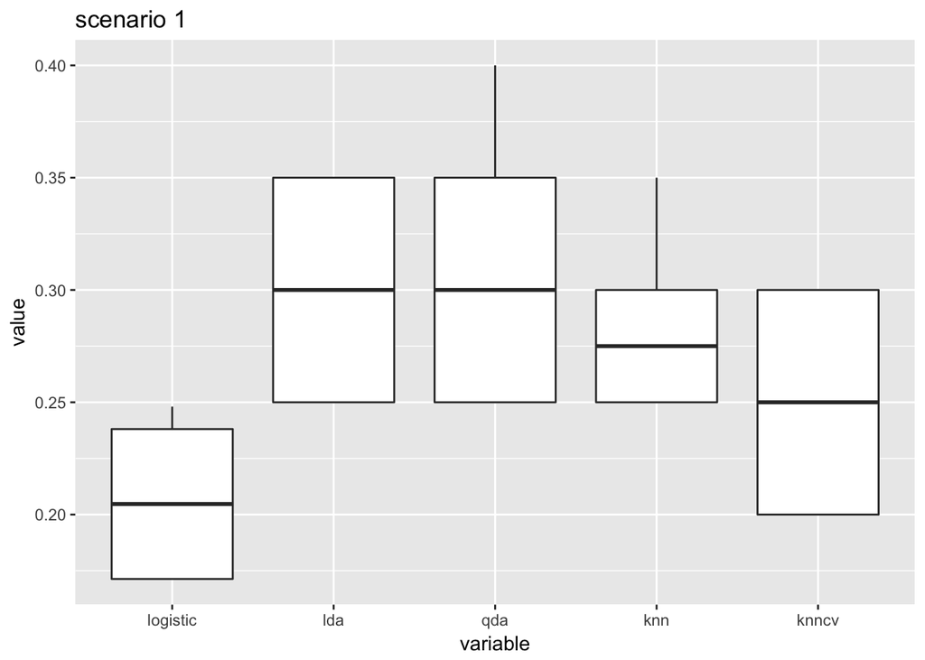

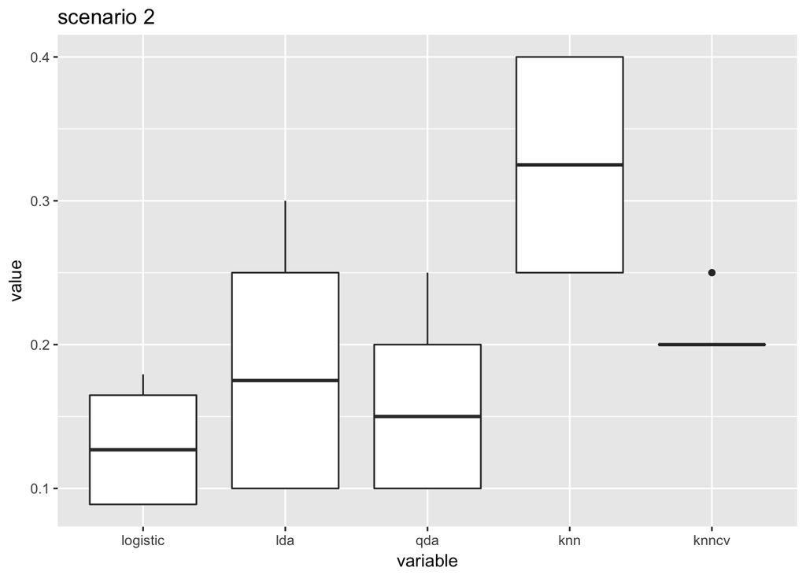

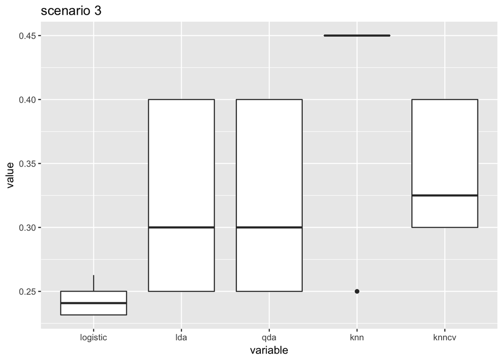

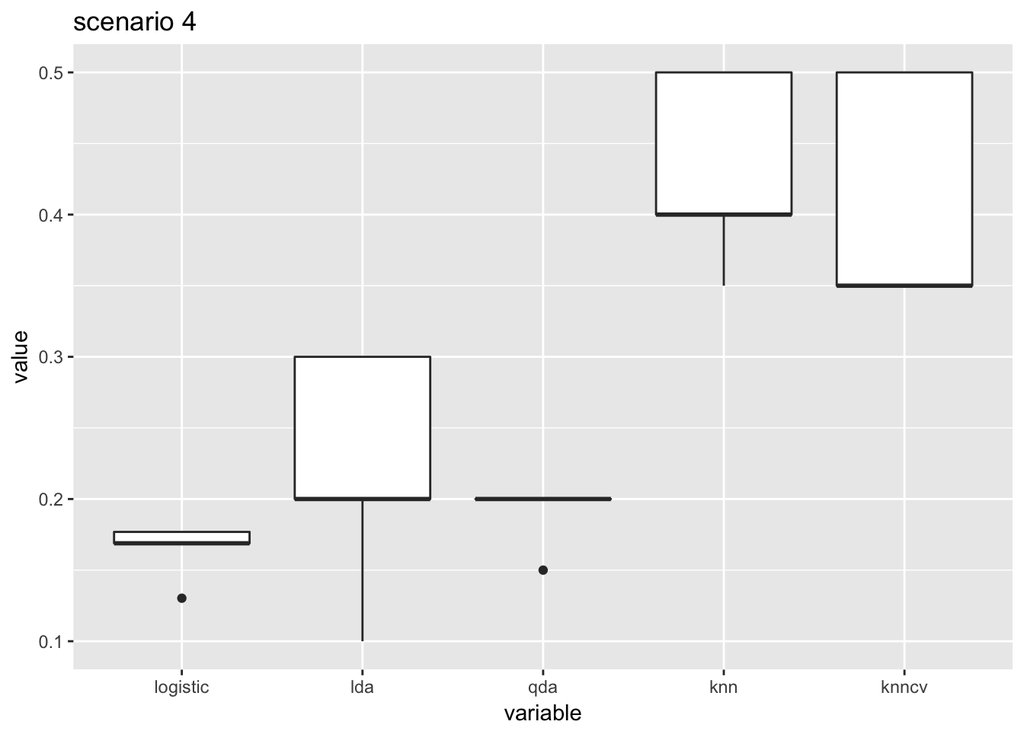

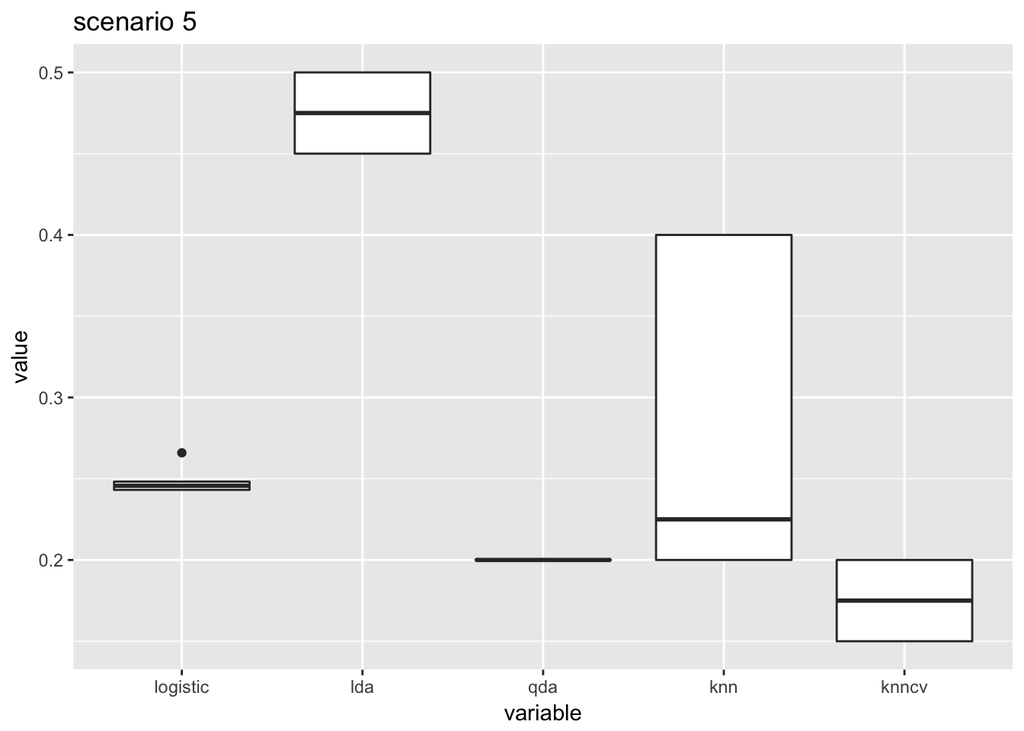

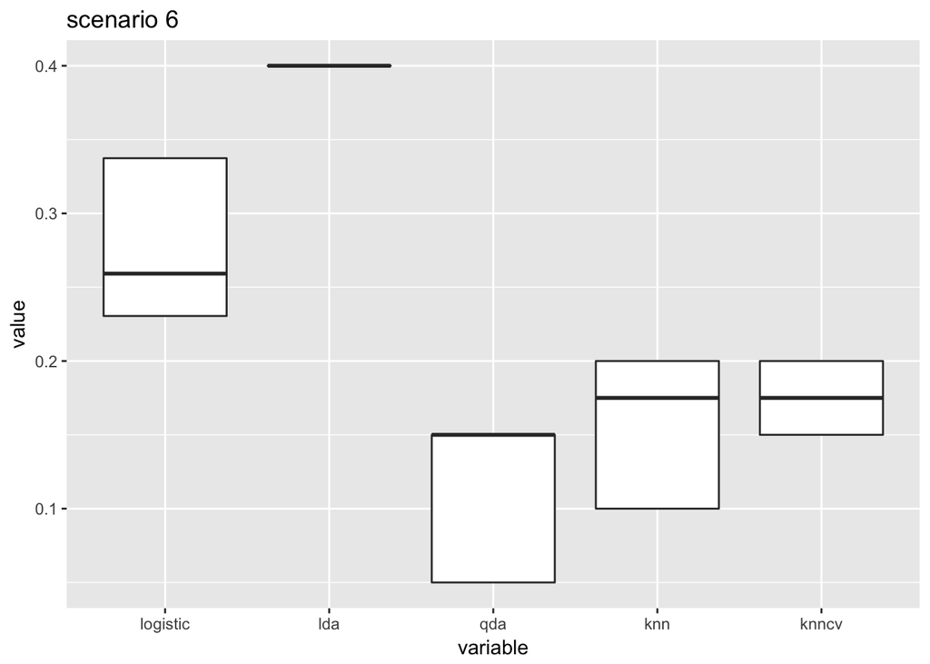

```r
listsmelt <- list(scenario1melt, scenario2melt, scenario3melt,
                  scenario4melt, scenario5melt, scenario6melt)

for(i in 1:6){
  print(ggplot(listsmelt[[i]], aes(x = variable, y = value)) + geom_boxplot() + ggtitle(paste("scenario", i)))
}
```